# task15

Dovile Oganauskaite

2016 m lapkritis 10 d

Uždavinys:

Jums reikia atlikti paprastą tiesinę regresiją. Prognozuojamas kintamasis y, regresosrius x. Duomenų failas:

https://github.com/1vbutkus/Econometrics1/blob/master/task15/data.csv

1. Įvertinti paprastosios tiesinės regresijos modelį. Pateikti modelio `summary` ir pakomentuoti ką reiškia gauti skaičiai. Kaip interpretuoti gautus rezultatus?
2. Padarykite modelio prognozes taškuose $0, 0.3, 0.5$.
3. Išbrėžkite kintamųjų sklaidos diagramą kartu su tiesinės regresijos tiese ir naujomis prognozėmis. Grafiką pateikite su pilna legena, kurioje būtų nurodyti visi žymėjimai.
4. Pakomentuokite ar tinkamas šis modelis duotiems duomenims. Ar galite pateikti tobulinimo pasiūlymų?
5. Įvertinti paprastosios tiesinės regresijos modelį. Pateikti modelio `summary` ir pakomentuoti ką reiškia gauti skaičiai. Kaip interpretuoti gautus rezultatus?

Iš pradžių nuskaitome failą.

```r
duom=read.csv("C:/Users/As/Desktop/New Folder (2)/task15/data.csv", stringsAsFactors = FALSE)
```

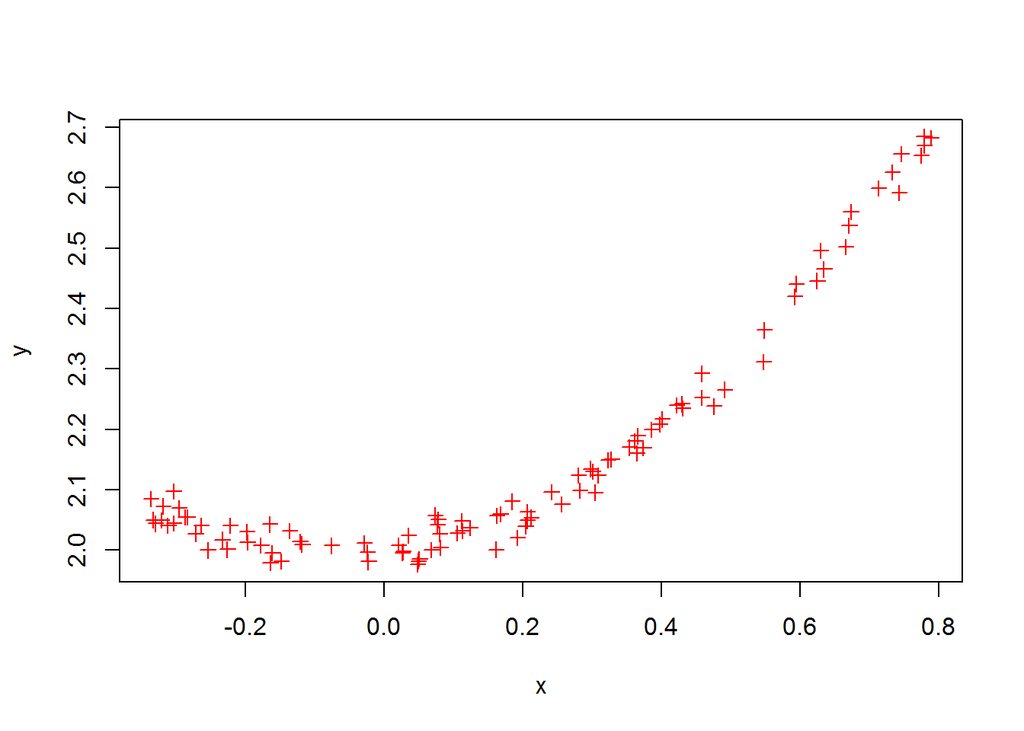

```r
a = duom$x # x - regresorius
b = duom$y # y - prognozuojamas kintamasis
plot(a, b, xlab = "x", ylab = "y", pch = 3, col = '2')  # Grafiškai pavaizduojame kintamųjų sklaidą
```

```r
modelis <- lm(b~a)
summary(modelis)
```

```
##
## Call:
## lm(formula = b ~ a)
##
## Residuals:
##      Min       1Q   Median       3Q      Max
## -0.14936 -0.08639 -0.04626  0.08815  0.21943
##
## Coefficients:
##             Estimate Std. Error t value Pr(>|t|)
## (Intercept)  2.06843    0.01205  171.58   <2e-16 ***
## a            0.50934    0.03225   15.79   <2e-16 ***
## ---
## Signif. codes:  0 '***' 0.001 '**' 0.01 '*' 0.05 '.' 0.1 ' ' 1
##
## Residual standard error: 0.1065 on 98 degrees of freedom
## Multiple R-squared:  0.7179, Adjusted R-squared:  0.715
## F-statistic: 249.4 on 1 and 98 DF,  p-value: < 2.2e-16
```

Funkcijos išvestyje matome: Iškviestos funkcijos formulė Likutis (‘Residuals’): minimumo taškas (‘Min’), pirmas kvartilis (‘1Q’), mediana (2kvartilis) (‘Median’), 3 kvartilis (‘3Q’) bei maksimumo taškas (‘Max’). Koeficientai: įvertis (‘Estimate’), standartinė paklaida (‘Standard error’), statistika (‘t-statistic’) ir tikimybė (‘p-value’) Reikšmingumo kodai, paprasčiau, tikimybės kategorijos Duomenų standartinė paklaida: 0.1065 su 98 laivės laipsniu Pakeltas R kvadratu ir pritaikytas R kvadratu parodo kiek mūsų modelis yra tinkamas Fišerio skirstinio statistika (‘F-statistic’) Tikimybė (‘p-value’)

2. Padarykite modelio prognozes taškuose $0, 0.3, 0.5$.

```r
newa = c(0, 0.3, 0.5)  # Fiksuojame naują  kintamąjį 'newa'
newb = predict(modelis, newdata = data.frame(a=newa))
newb
```

```
##        1        2        3
## 2.068428 2.221230 2.323098
```

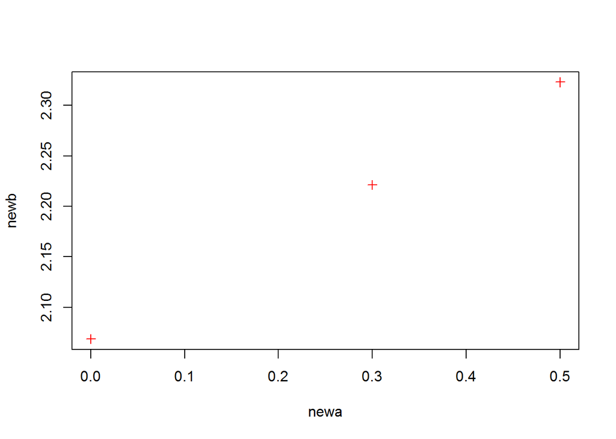

```r
plot(newa, newb, pch = 3, col = '2')  # Pažiūrime, kur yra naujieji taškai
```

3. Išbrėžkite kintamųjų sklaidos diagramą kartu su tiesinės regresijos tiese ir naujomis prognozėmis. Grafiką pateikite su pilna legena, kurioje būtų nurodyti visi žymėjimai.

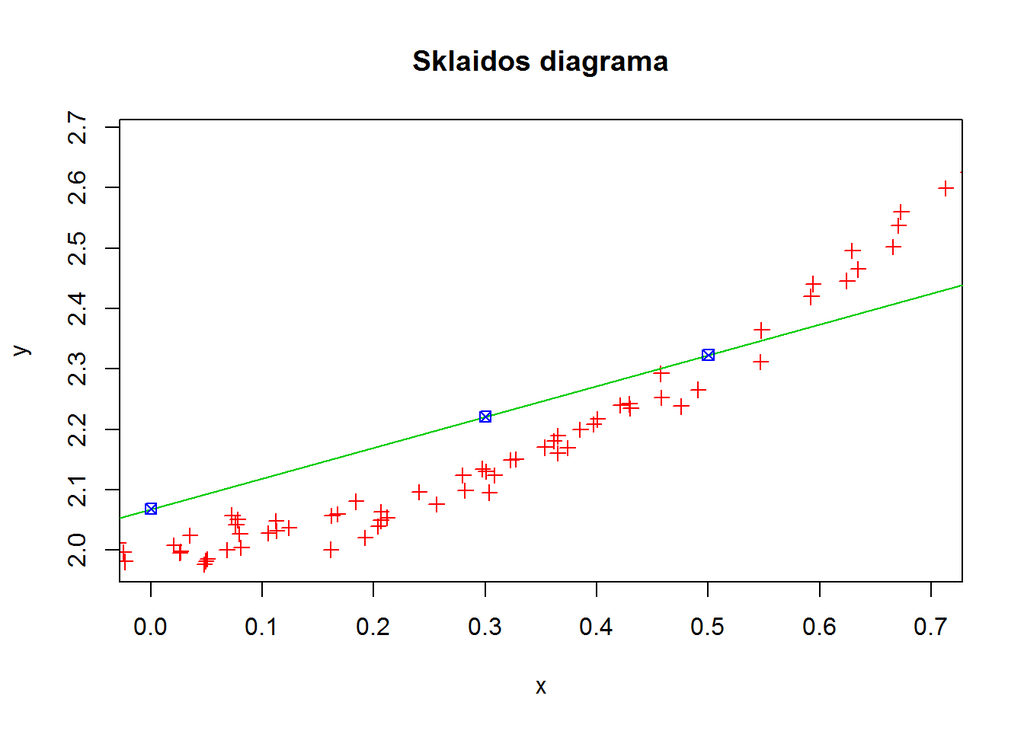

```r
plot(a, b, main = 'Sklaidos diagrama', xlab = "x", ylab = "y", xlim = c(0, 0.7), pch = 3, col = '2')  # Nubraižome pirminių duomenų sklaidą
modelis <- lm(b~a)  # Pakartojame modelį, jog būtų galima nubrėžti tiesę
abline(modelis, pch = 3, col = '3')  # Nubrėžiame tiesinės regresijos tiesę
newa = c(0, 0.3, 0.5)
newb = predict(modelis, newdata = data.frame(a=newa))  # Naudosime naujuosius taškus grafikui
points(newa, newb, pch = 7, col = '4')  # Pažymime naujai išvestus taškus grafike
legend( 0, 0.7, c("Pradinė sklaida", "Tiesinė regresija", "Naujos reikšmės"), lty = c(0, 1, 0), pch = c(3, 3, 7), col = c('2','3','4'))  # Susikuriame legendą
```

4. Pakomentuokite ar tinkamas šis modelis duotiems duomenims. Ar galite pateikti tobulinimo pasiūlymų?

Modelis nėra tinkamas duotiems duomenimis, kadangi funkcija yra “išriesta” ir jos linkyje esanti reikšmė yra per daug toli nuo tiesinės funkcijos reikšmės.